# Invistigate_tmdb_Hamdy,Abdel-Shafy

## Udacity Data Analysis Advanced - Nanodegree Program

## Project 1: The TMDb movie data analysis

### By: Hamdy Abdel-Shafy

#### April 2021

- Introduction
- Data Wrangling
- Exploratory Data Analysis
- Conclusions

## Introduction

Here is a brief introduction to the TMDb movie dataset I have been selected for analysis. This dataset was cleaned and provided by Udacity. The dataset contains information about more than 10,000 movies collected from The Movie Database (TMDb), including user ratings and revenue. It contains 21 variables such as imdb_id, revenue, budget, and vote_count.

#### **Here are some questions that can be answered after analyizing this dataset**

> 1. Which movie had the highest and which one had the lowest profit?
> 2. Which movie had the highest and which one had the lowest budget?
> 3. Which movie had the highest and which one had the lowest revenue?
> 4. What is the average runtime for all movies?
> 5. How the profitability of the movies distributed over the years?
> 6. How movie genres changed over time?
> 7. Which genres have the highest and lowest profit, budget and revenue?

```python
# Import libraries required for data screening, analyses and visualisations
import pandas as pd
import numpy as np
import csv
from datetime import datetime
import matplotlib.pyplot as plt
%matplotlib inline
import seaborn as sns
sns.set_style('darkgrid')
```

## Data Wrangling

> The dataset will be checked and then only relevent data will be kept. The rest will be deleted.

### General Properties

```python
# Load the data and print out a few lines.
# Perform operations to inspect data types and look for instances of missing or possibly errant data.

#loading the csv file and storing it in the variable "tmbd_data"
tmdb_data = pd.read_csv('tmdb-movies.csv')

#printing first five rows with defined columns of tmdb-movies database
tmdb_data.head()
```

|  | id | imdb_id | popularity | budget | revenue | original_title | cast | homepage | director | tagline | ... | overview | runtime | genres | production_companies | release_date | vote_count | vote_average | release_year | budget_adj | revenue_adj |
| --- | --- | --- | --- | --- | --- | --- | --- | --- | --- | --- | --- | --- | --- | --- | --- | --- | --- | --- | --- | --- | --- |
| 0 | 135397 | tt0369610 | 32.985763 | 150000000 | 1513528810 | Jurassic World | Chris Pratt\|Bryce Dallas Howard\|Irrfan Khan\|Vi... | http://www.jurassicworld.com/ | Colin Trevorrow | The park is open. | ... | Twenty-two years after the events of Jurassic ... | 124 | Action\|Adventure\|Science Fiction\|Thriller | Universal Studios\|Amblin Entertainment\|Legenda... | 6/9/15 | 5562 | 6.5 | 2015 | 1.379999e+08 | 1.392446e+09 |
| 1 | 76341 | tt1392190 | 28.419936 | 150000000 | 378436354 | Mad Max: Fury Road | Tom Hardy\|Charlize Theron\|Hugh Keays-Byrne\|Nic... | http://www.madmaxmovie.com/ | George Miller | What a Lovely Day. | ... | An apocalyptic story set in the furthest reach... | 120 | Action\|Adventure\|Science Fiction\|Thriller | Village Roadshow Pictures\|Kennedy Miller Produ... | 5/13/15 | 6185 | 7.1 | 2015 | 1.379999e+08 | 3.481613e+08 |
| 2 | 262500 | tt2908446 | 13.112507 | 110000000 | 295238201 | Insurgent | Shailene Woodley\|Theo James\|Kate Winslet\|Ansel... | http://www.thedivergentseries.movie/#insurgent | Robert Schwentke | One Choice Can Destroy You | ... | Beatrice Prior must confront her inner demons ... | 119 | Adventure\|Science Fiction\|Thriller | Summit Entertainment\|Mandeville Films\|Red Wago... | 3/18/15 | 2480 | 6.3 | 2015 | 1.012000e+08 | 2.716190e+08 |
| 3 | 140607 | tt2488496 | 11.173104 | 200000000 | 2068178225 | Star Wars: The Force Awakens | Harrison Ford\|Mark Hamill\|Carrie Fisher\|Adam D... | http://www.starwars.com/films/star-wars-episod... | J.J. Abrams | Every generation has a story. | ... | Thirty years after defeating the Galactic Empi... | 136 | Action\|Adventure\|Science Fiction\|Fantasy | Lucasfilm\|Truenorth Productions\|Bad Robot | 12/15/15 | 5292 | 7.5 | 2015 | 1.839999e+08 | 1.902723e+09 |
| 4 | 168259 | tt2820852 | 9.335014 | 190000000 | 1506249360 | Furious 7 | Vin Diesel\|Paul Walker\|Jason Statham\|Michelle ... | http://www.furious7.com/ | James Wan | Vengeance Hits Home | ... | Deckard Shaw seeks revenge against Dominic Tor... | 137 | Action\|Crime\|Thriller | Universal Pictures\|Original Film\|Media Rights ... | 4/1/15 | 2947 | 7.3 | 2015 | 1.747999e+08 | 1.385749e+09 |

5 rows × 21 columns

```python
#printing last five rows with defined columns of tmdb-movies database
tmdb_data.tail()
```

|  | id | imdb_id | popularity | budget | revenue | original_title | cast | homepage | director | tagline | ... | overview | runtime | genres | production_companies | release_date | vote_count | vote_average | release_year | budget_adj | revenue_adj |
| --- | --- | --- | --- | --- | --- | --- | --- | --- | --- | --- | --- | --- | --- | --- | --- | --- | --- | --- | --- | --- | --- |
| 10861 | 21 | tt0060371 | 0.080598 | 0 | 0 | The Endless Summer | Michael Hynson\|Robert August\|Lord 'Tally Ho' B... | NaN | Bruce Brown | NaN | ... | The Endless Summer, by Bruce Brown, is one of ... | 95 | Documentary | Bruce Brown Films | 6/15/66 | 11 | 7.4 | 1966 | 0.000000 | 0.0 |
| 10862 | 20379 | tt0060472 | 0.065543 | 0 | 0 | Grand Prix | James Garner\|Eva Marie Saint\|Yves Montand\|Tosh... | NaN | John Frankenheimer | Cinerama sweeps YOU into a drama of speed and ... | ... | Grand Prix driver Pete Aron is fired by his te... | 176 | Action\|Adventure\|Drama | Cherokee Productions\|Joel Productions\|Douglas ... | 12/21/66 | 20 | 5.7 | 1966 | 0.000000 | 0.0 |
| 10863 | 39768 | tt0060161 | 0.065141 | 0 | 0 | Beregis Avtomobilya | Innokentiy Smoktunovskiy\|Oleg Efremov\|Georgi Z... | NaN | Eldar Ryazanov | NaN | ... | An insurance agent who moonlights as a carthie... | 94 | Mystery\|Comedy | Mosfilm | 1/1/66 | 11 | 6.5 | 1966 | 0.000000 | 0.0 |
| 10864 | 21449 | tt0061177 | 0.064317 | 0 | 0 | What's Up, Tiger Lily? | Tatsuya Mihashi\|Akiko Wakabayashi\|Mie Hama\|Joh... | NaN | Woody Allen | WOODY ALLEN STRIKES BACK! | ... | In comic Woody Allen's film debut, he took the... | 80 | Action\|Comedy | Benedict Pictures Corp. | 11/2/66 | 22 | 5.4 | 1966 | 0.000000 | 0.0 |
| 10865 | 22293 | tt0060666 | 0.035919 | 19000 | 0 | Manos: The Hands of Fate | Harold P. Warren\|Tom Neyman\|John Reynolds\|Dian... | NaN | Harold P. Warren | It's Shocking! It's Beyond Your Imagination! | ... | A family gets lost on the road and stumbles up... | 74 | Horror | Norm-Iris | 11/15/66 | 15 | 1.5 | 1966 | 127642.279154 | 0.0 |

5 rows × 21 columns

It looks OK. We can see the information that cen be used to answer the proposed questions. However, some columns contain multiple entries seperated by '|' character, e.g. Cast, keyword, genres, and production_companies. Now lets take a look at some of the general properties of the data:

```python
tmdb_data.shape
```

```
(10866, 21)
```

```python
tmdb_data.columns
```

```
Index(['id', 'imdb_id', 'popularity', 'budget', 'revenue', 'original_title',
       'cast', 'homepage', 'director', 'tagline', 'keywords', 'overview',
       'runtime', 'genres', 'production_companies', 'release_date',
       'vote_count', 'vote_average', 'release_year', 'budget_adj',
       'revenue_adj'],
      dtype='object')
```

```python
tmdb_data.nunique()
```

```
id                      10865
imdb_id                 10855
popularity              10814
budget                    557
revenue                  4702
original_title          10571
cast                    10719
homepage                 2896
director                 5067
tagline                  7997
keywords                 8804
overview                10847
runtime                   247
genres                   2039
production_companies     7445
release_date             5909
vote_count               1289
vote_average               72
release_year               56
budget_adj               2614
revenue_adj              4840
dtype: int64
```

```python
tmdb_data.info()
```

```
<class 'pandas.core.frame.DataFrame'>
RangeIndex: 10866 entries, 0 to 10865
Data columns (total 21 columns):
 #   Column                Non-Null Count  Dtype
---  ------                --------------  -----
 0   id                    10866 non-null  int64
 1   imdb_id               10856 non-null  object
 2   popularity            10866 non-null  float64
 3   budget                10866 non-null  int64
 4   revenue               10866 non-null  int64
 5   original_title        10866 non-null  object
 6   cast                  10790 non-null  object
 7   homepage              2936 non-null   object
 8   director              10822 non-null  object
 9   tagline               8042 non-null   object
 10  keywords              9373 non-null   object
 11  overview              10862 non-null  object
 12  runtime               10866 non-null  int64
 13  genres                10843 non-null  object
 14  production_companies  9836 non-null   object
 15  release_date          10866 non-null  object
 16  vote_count            10866 non-null  int64
 17  vote_average          10866 non-null  float64
 18  release_year          10866 non-null  int64
 19  budget_adj            10866 non-null  float64
 20  revenue_adj           10866 non-null  float64
dtypes: float64(4), int64(6), object(11)
memory usage: 1.7+ MB
```

- From previous steps, we can see that data contains 10866 rows and 21 columns.
- Some variables have few missing values such as imdb_id, cast, director, overview and genres. While there some others missed many more values like: homepage, tagline, keywords and production_companies.
- We deal with these missing observaions later in the Data Quality section. We will also exclude unnecessary columns from dataset, e.g. imdb_id, homepage, tagline, overview.

**General statistics of the data:**

```python
tmdb_data.describe()
```

|  | id | popularity | budget | revenue | runtime | vote_count | vote_average | release_year | budget_adj | revenue_adj |
| --- | --- | --- | --- | --- | --- | --- | --- | --- | --- | --- |
| count | 10866.000000 | 10866.000000 | 1.086600e+04 | 1.086600e+04 | 10866.000000 | 10866.000000 | 10866.000000 | 10866.000000 | 1.086600e+04 | 1.086600e+04 |
| mean | 66064.177434 | 0.646441 | 1.462570e+07 | 3.982332e+07 | 102.070863 | 217.389748 | 5.974922 | 2001.322658 | 1.755104e+07 | 5.136436e+07 |
| std | 92130.136561 | 1.000185 | 3.091321e+07 | 1.170035e+08 | 31.381405 | 575.619058 | 0.935142 | 12.812941 | 3.430616e+07 | 1.446325e+08 |
| min | 5.000000 | 0.000065 | 0.000000e+00 | 0.000000e+00 | 0.000000 | 10.000000 | 1.500000 | 1960.000000 | 0.000000e+00 | 0.000000e+00 |
| 25% | 10596.250000 | 0.207583 | 0.000000e+00 | 0.000000e+00 | 90.000000 | 17.000000 | 5.400000 | 1995.000000 | 0.000000e+00 | 0.000000e+00 |
| 50% | 20669.000000 | 0.383856 | 0.000000e+00 | 0.000000e+00 | 99.000000 | 38.000000 | 6.000000 | 2006.000000 | 0.000000e+00 | 0.000000e+00 |
| 75% | 75610.000000 | 0.713817 | 1.500000e+07 | 2.400000e+07 | 111.000000 | 145.750000 | 6.600000 | 2011.000000 | 2.085325e+07 | 3.369710e+07 |
| max | 417859.000000 | 32.985763 | 4.250000e+08 | 2.781506e+09 | 900.000000 | 9767.000000 | 9.200000 | 2015.000000 | 4.250000e+08 | 2.827124e+09 |

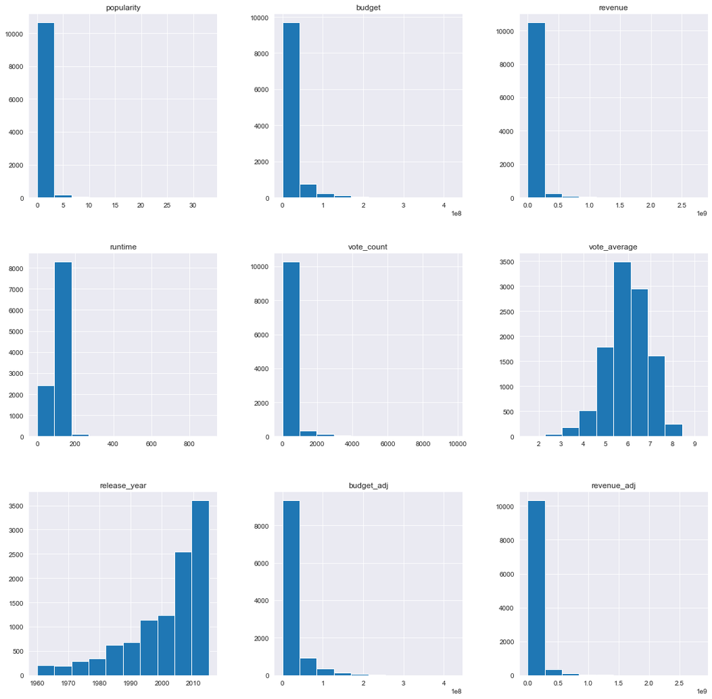

```python
# Visualizing raw data using Histogram
# Note: We will ignore the id column since it doesn't make any sense for plotting

tmdb_data.drop(['id'], axis=1).hist(figsize=( 18,18));
```

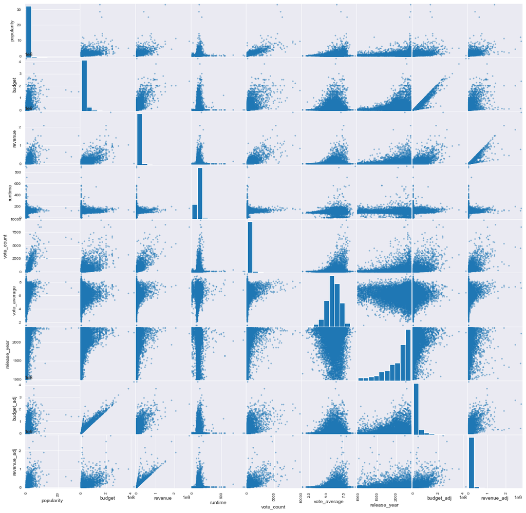

```python
# Visualizing raw data with scatter plot
pd.plotting.scatter_matrix(tmdb_data.drop(['id'], axis=1), figsize=(18,18));
```

```python
# correlation between variables
df_corr = tmdb_data.drop(['id'], axis=1).corr()
```

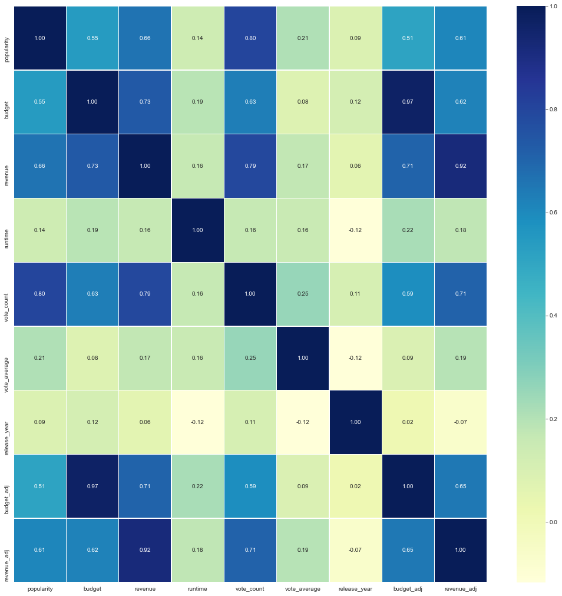

```python
f, ax= plt.subplots(figsize=(18,18))
sns.heatmap(df_corr, annot=True, linewidths=.3, cmap="YlGnBu", fmt='.2f', ax=ax)
plt.show()
```

### Data Cleaning

**1. Removing Unused columns**

```python
#create a list of columns to be deleted
del_col=['id', 'imdb_id', 'budget_adj', 'revenue_adj', 'homepage', 'tagline', 'keywords', 'overview', 'vote_count', 'vote_average']

#delete the list of columns
tmdb_data= tmdb_data.drop(del_col,1)

#previewing the new dataset
tmdb_data.head(3)
```

|  | popularity | budget | revenue | original_title | cast | director | runtime | genres | production_companies | release_date | release_year |
| --- | --- | --- | --- | --- | --- | --- | --- | --- | --- | --- | --- |
| 0 | 32.985763 | 150000000 | 1513528810 | Jurassic World | Chris Pratt\|Bryce Dallas Howard\|Irrfan Khan\|Vi... | Colin Trevorrow | 124 | Action\|Adventure\|Science Fiction\|Thriller | Universal Studios\|Amblin Entertainment\|Legenda... | 6/9/15 | 2015 |
| 1 | 28.419936 | 150000000 | 378436354 | Mad Max: Fury Road | Tom Hardy\|Charlize Theron\|Hugh Keays-Byrne\|Nic... | George Miller | 120 | Action\|Adventure\|Science Fiction\|Thriller | Village Roadshow Pictures\|Kennedy Miller Produ... | 5/13/15 | 2015 |
| 2 | 13.112507 | 110000000 | 295238201 | Insurgent | Shailene Woodley\|Theo James\|Kate Winslet\|Ansel... | Robert Schwentke | 119 | Adventure\|Science Fiction\|Thriller | Summit Entertainment\|Mandeville Films\|Red Wago... | 3/18/15 | 2015 |

**2. Remove duplicate rows (if it is existed)**

```python
tmdb_data.drop_duplicates(keep ='first', inplace=True)
rows, col = tmdb_data.shape
```

**3 . Remov zero values from budget and revenue columns**

```python
# create a seperate list of revenue, budget and runtime columns
temp_list=['budget', 'revenue', 'runtime']

#Replace all values of '0' by NAN in the previous list
tmdb_data[temp_list] = tmdb_data[temp_list].replace(0, np.NAN)

#Remove all row with NaN value in temp_list
tmdb_data.dropna(subset = temp_list, inplace = True)

rows, col = tmdb_data.shape
```

**4. Change the formats of release date, budget and revenue columns into relevant formats**

```python
# check the data types
tmdb_data.dtypes
```

```
popularity              float64
budget                  float64
revenue                 float64
original_title           object
cast                     object
director                 object
runtime                 float64
genres                   object
production_companies     object
release_date             object
release_year              int64
dtype: object
```

```python
#changing data type of release_date
tmdb_data.release_date = pd.to_datetime(tmdb_data['release_date'])
```

```python
#changing data type of budget and revenue
change_type=['popularity', 'budget', 'revenue', 'runtime']
tmdb_data[change_type]=tmdb_data[change_type].applymap(np.int64)
```

```python
# check the data types of the cleaned dataset
tmdb_data.dtypes
```

```
popularity                       int64
budget                           int64
revenue                          int64
original_title                  object
cast                            object
director                        object
runtime                          int64
genres                          object
production_companies            object
release_date            datetime64[ns]
release_year                     int64
dtype: object
```

**5. Drop the null values in cast, director, genres columns**

```python
list = ['cast', 'director', 'genres']
tmdb_data.dropna(subset = list, how='any', inplace=True)
```

```python
# Confirm rows dropped
tmdb_data.isnull().sum()
```

```
popularity               0
budget                   0
revenue                  0
original_title           0
cast                     0
director                 0
runtime                  0
genres                   0
production_companies    44
release_date             0
release_year             0
dtype: int64
```

```python
tmdb_data.describe()
```

|  | popularity | budget | revenue | runtime | release_year |
| --- | --- | --- | --- | --- | --- |
| count | 3849.000000 | 3.849000e+03 | 3.849000e+03 | 3849.000000 | 3849.000000 |
| mean | 0.710834 | 3.724886e+07 | 1.078148e+08 | 109.217459 | 2001.258249 |
| std | 1.473180 | 4.221699e+07 | 1.766175e+08 | 19.914141 | 11.285642 |
| min | 0.000000 | 1.000000e+00 | 2.000000e+00 | 15.000000 | 1960.000000 |
| 25% | 0.000000 | 1.000000e+07 | 1.367069e+07 | 95.000000 | 1995.000000 |
| 50% | 0.000000 | 2.400000e+07 | 4.490726e+07 | 106.000000 | 2004.000000 |
| 75% | 1.000000 | 5.000000e+07 | 1.243052e+08 | 119.000000 | 2010.000000 |
| max | 32.000000 | 4.250000e+08 | 2.781506e+09 | 338.000000 | 2015.000000 |

```python
tmdb_data.info()
```

```
<class 'pandas.core.frame.DataFrame'>
Int64Index: 3849 entries, 0 to 10848
Data columns (total 11 columns):
 #   Column                Non-Null Count  Dtype
---  ------                --------------  -----
 0   popularity            3849 non-null   int64
 1   budget                3849 non-null   int64
 2   revenue               3849 non-null   int64
 3   original_title        3849 non-null   object
 4   cast                  3849 non-null   object
 5   director              3849 non-null   object
 6   runtime               3849 non-null   int64
 7   genres                3849 non-null   object
 8   production_companies  3805 non-null   object
 9   release_date          3849 non-null   datetime64[ns]
 10  release_year          3849 non-null   int64
dtypes: datetime64[ns](1), int64(5), object(5)
memory usage: 360.8+ KB
```

## Exploratory Data Analysis

### Research Question 1 (Which movie had the highest and which one had the lowest profit?)

```python
# create new variable calculating the profit of each movie
tmdb_data.insert(3,'profit',tmdb_data['revenue']-tmdb_data['budget'])
```

```python
#preview changes in the new dataset
tmdb_data.head(3)
```

|  | popularity | budget | revenue | profit | original_title | cast | director | runtime | genres | production_companies | release_date | release_year |
| --- | --- | --- | --- | --- | --- | --- | --- | --- | --- | --- | --- | --- |
| 0 | 32 | 150000000 | 1513528810 | 1363528810 | Jurassic World | Chris Pratt\|Bryce Dallas Howard\|Irrfan Khan\|Vi... | Colin Trevorrow | 124 | Action\|Adventure\|Science Fiction\|Thriller | Universal Studios\|Amblin Entertainment\|Legenda... | 2015-06-09 | 2015 |
| 1 | 28 | 150000000 | 378436354 | 228436354 | Mad Max: Fury Road | Tom Hardy\|Charlize Theron\|Hugh Keays-Byrne\|Nic... | George Miller | 120 | Action\|Adventure\|Science Fiction\|Thriller | Village Roadshow Pictures\|Kennedy Miller Produ... | 2015-05-13 | 2015 |
| 2 | 13 | 110000000 | 295238201 | 185238201 | Insurgent | Shailene Woodley\|Theo James\|Kate Winslet\|Ansel... | Robert Schwentke | 119 | Adventure\|Science Fiction\|Thriller | Summit Entertainment\|Mandeville Films\|Red Wago... | 2015-03-18 | 2015 |

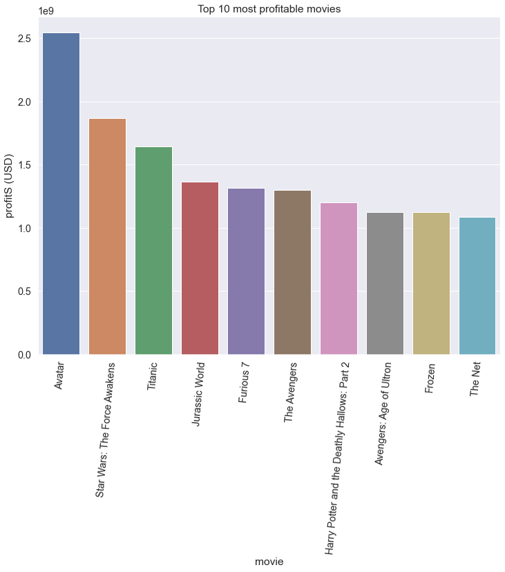

```python
#Top 10 most profitable movies

movies_profit = tmdb_data[["original_title", "profit"]]
sns.set(rc={'figure.figsize':(12,9)}, font_scale=1.3)

ax = sns.barplot(
    movies_profit.sort_values(by = "profit", ascending=False).head(10).original_title,
    movies_profit.sort_values(by = "profit", ascending=False).head(10).profit)

#rotate x-axis' text
for item in ax.get_xticklabels():
    item.set_rotation(85)

ax.set(xlabel='movie', ylabel='profitS (USD)', title = 'Top 10 most profitable movies')
plt.show()
```

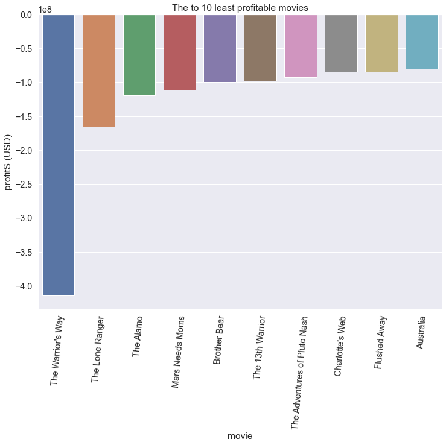

```python
#Top 10 least profitable movies

movies_profit = tmdb_data[["original_title", "profit"]]
sns.set(rc={'figure.figsize':(12,9)}, font_scale=1.3)

ax = sns.barplot(
    movies_profit.sort_values(by = "profit", ascending=True).head(10).original_title,
    movies_profit.sort_values(by = "profit", ascending=True).head(10).profit)

#rotate x-axis' text
for item in ax.get_xticklabels():
    item.set_rotation(85)

ax.set(xlabel='movie', ylabel='profitS (USD)', title = 'The to 10 least profitable movies')
plt.show()
```

Here, we can see that Avatar had the highest profit with 2,544,505,847 USD. While, The Warrior's Way had the lowest profit with -413,912,431 USD.

### Research Question 2 (Which movie had the highest and which one had the lowest budget?)

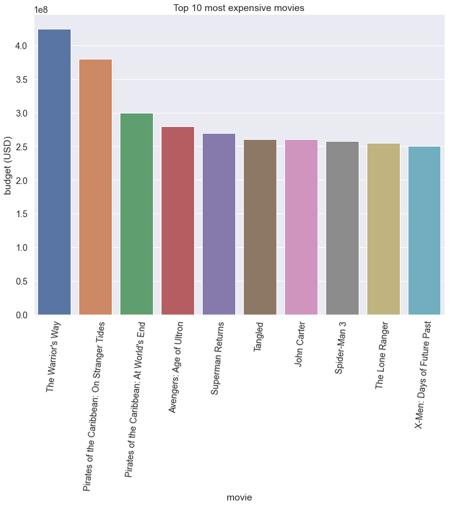

```python
#Top 10 most expensive movies

movies_budget = tmdb_data[["original_title", "budget"]]
sns.set(rc={'figure.figsize':(12,9)}, font_scale=1.3)

ax = sns.barplot(
    movies_budget.sort_values(by = "budget", ascending=False).head(10).original_title,
    movies_budget.sort_values(by = "budget", ascending=False).head(10).budget)

#rotate x-axis' text
for item in ax.get_xticklabels():
    item.set_rotation(85)

ax.set(xlabel='movie', ylabel='budget (USD)', title = 'Top 10 most expensive movies')
plt.show()
```

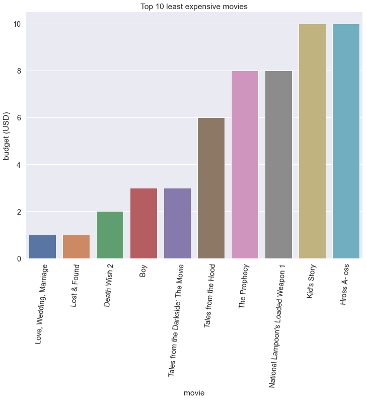

```python
#Top 10 least expensive movies

movies_budget = tmdb_data[["original_title", "budget"]]
sns.set(rc={'figure.figsize':(12,9)}, font_scale=1.3)

ax = sns.barplot(
    movies_budget.sort_values(by = "budget", ascending=True).head(10).original_title,
    movies_budget.sort_values(by = "budget", ascending=True).head(10).budget)

#rotate x-axis' text
for item in ax.get_xticklabels():
    item.set_rotation(85)

ax.set(xlabel='movie', ylabel='budget (USD)', title = 'Top 10 least expensive movies')
plt.show()
```

Here, we can see that The Warrior's Way had the highest budget with 425,000,000 USD. While, Love, Wedding, Marriage had the lowest budget with 1 USD.

### Research Question 3 (Which movie had the highest and which one had the lowest revenue?)

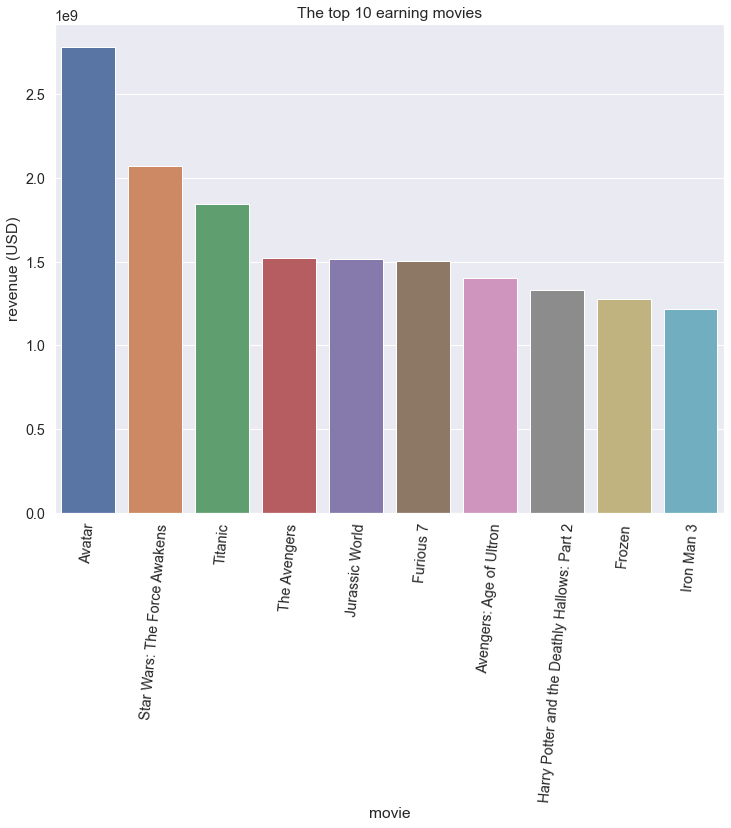

```python
#Top 10 earning movies

movies_revenue = tmdb_data[["original_title", "revenue"]]
sns.set(rc={'figure.figsize':(12,9)}, font_scale=1.3)

ax = sns.barplot(
    movies_revenue.sort_values(by = "revenue", ascending=False).head(10).original_title,
    movies_revenue.sort_values(by = "revenue", ascending=False).head(10).revenue)

#rotate x-axis' text
for item in ax.get_xticklabels():
    item.set_rotation(85)

ax.set(xlabel='movie', ylabel='revenue (USD)', title = 'The top 10 earning movies')
plt.show()
```

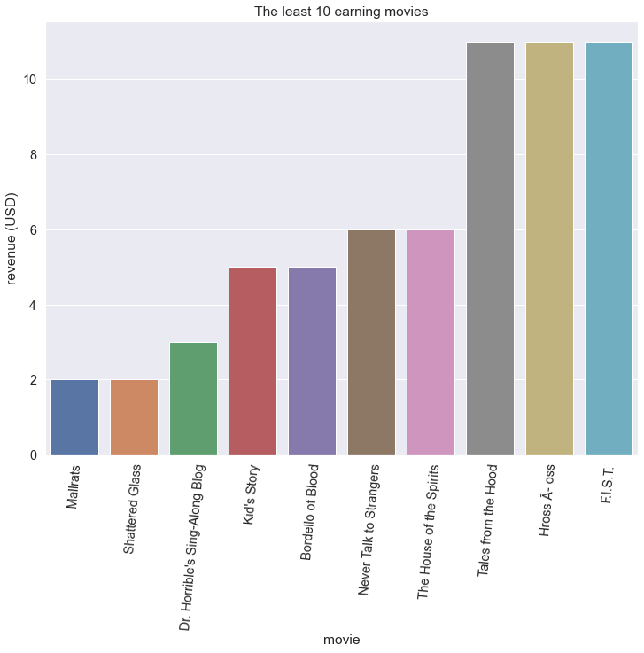

```python
#Least 10 earning movies

movies_revenue = tmdb_data[["original_title", "revenue"]]
sns.set(rc={'figure.figsize':(12,9)}, font_scale=1.3)

ax = sns.barplot(
    movies_revenue.sort_values(by = "revenue", ascending=True).head(10).original_title,
    movies_revenue.sort_values(by = "revenue", ascending=True).head(10).revenue)

#rotate x-axis' text
for item in ax.get_xticklabels():
    item.set_rotation(85)

ax.set(xlabel='movie', ylabel='revenue (USD)', title = 'The least 10 earning movies')
plt.show()
```

Here, we can see that Avatar had the highest revenue with 2,781,505,847 USD. While, Mallarats had the lowest revenue with 2 USD.

```python
# Details about the runtime movies
tmdb_data['runtime'].describe()
```

```
count    3849.000000
mean      109.217459
std        19.914141
min        15.000000
25%        95.000000
50%       106.000000
75%       119.000000
max       338.000000
Name: runtime, dtype: float64
```

As we see, the average runtime for all movies is 109 minutes. Since the median (106) is less than the mean (109), the distribution of the runtime is skewed to the right. Most of movies had runtime between 95 and 119 minutes. The minimum duration was 15 and the maximum duration was 338 minutes.

### Research Question 5 (How the profitability of the movies distributed over the years?)

[figure not shown]

```python
# Distribution of profit over the years

f,ax=plt.subplots(figsize=(20, 10))
tmdb_data[['release_year', 'profit']].groupby(['release_year']).sum().sort_values(["profit"], ascending=False).plot(kind="bar",  ax=ax);
ax.set(ylabel = 'USD', xlabel = 'Years', title = 'Distribution of profits over year')

plt.show()
```

From above figure, we can see that the year 2015 was the most profitable year for all movies in the current dataset.

### Research Question 6 (How movie genres changed over time?)

Let's take a look at the popularty of genres throughout the years.

```python
tmdb_data.genres.unique()
```

```
array(['Action|Adventure|Science Fiction|Thriller',
       'Adventure|Science Fiction|Thriller',
       'Action|Adventure|Science Fiction|Fantasy', ...,
       'Action|Drama|Horror|Thriller', 'Adventure|Animation|Drama',
       'Action|Adventure|Drama|War|Romance'], dtype=object)
```

As we can see, the data contains multiple entries delimitted by '|'. We need to split out the rows using split function.

```python
# Check original row count
tmdb_data.shape
```

```
(3849, 12)
```

```python
tmdb_data_genre = tmdb_data
# columns to split by "|"
tmdb_data_genre['genres'] = tmdb_data['genres'].apply(lambda x: x.split("|")[0])
```

```python
# Check new row count
tmdb_data_genre.shape
```

```
(3849, 12)
```

```python
# Confirm the action worked and geners is splitted out
tmdb_data_genre.genres.unique()
```

```
array(['Action', 'Adventure', 'Western', 'Science Fiction', 'Drama',
       'Family', 'Comedy', 'Crime', 'Romance', 'War', 'Thriller',
       'Fantasy', 'History', 'Mystery', 'Animation', 'Horror', 'Music',
       'Documentary', 'TV Movie'], dtype=object)
```

```python
tmdb_data_genre.head(3)
```

|  | popularity | budget | revenue | profit | original_title | cast | director | runtime | genres | production_companies | release_date | release_year |
| --- | --- | --- | --- | --- | --- | --- | --- | --- | --- | --- | --- | --- |
| 0 | 32 | 150000000 | 1513528810 | 1363528810 | Jurassic World | Chris Pratt\|Bryce Dallas Howard\|Irrfan Khan\|Vi... | Colin Trevorrow | 124 | Action | Universal Studios\|Amblin Entertainment\|Legenda... | 2015-06-09 | 2015 |
| 1 | 28 | 150000000 | 378436354 | 228436354 | Mad Max: Fury Road | Tom Hardy\|Charlize Theron\|Hugh Keays-Byrne\|Nic... | George Miller | 120 | Action | Village Roadshow Pictures\|Kennedy Miller Produ... | 2015-05-13 | 2015 |
| 2 | 13 | 110000000 | 295238201 | 185238201 | Insurgent | Shailene Woodley\|Theo James\|Kate Winslet\|Ansel... | Robert Schwentke | 119 | Adventure | Summit Entertainment\|Mandeville Films\|Red Wago... | 2015-03-18 | 2015 |

It looks good. Now, let's count the number of movies in each genre over the years.

```python
tmdb_genre_year = tmdb_data_genre.groupby(['release_year', 'genres']).count()['budget'].unstack()
```

```python
tmdb_genre_year.head(5)
```

| genres release_year | Action | Adventure | Animation | Comedy | Crime | Documentary | Drama | Family | Fantasy | History | Horror | Music | Mystery | Romance | Science Fiction | TV Movie | Thriller | War | Western |
| --- | --- | --- | --- | --- | --- | --- | --- | --- | --- | --- | --- | --- | --- | --- | --- | --- | --- | --- | --- |
| 1960 | 2.0 | NaN | NaN | 2.0 | NaN | NaN | 1.0 | NaN | NaN | NaN | NaN | NaN | NaN | NaN | NaN | NaN | NaN | NaN | NaN |
| 1961 | 1.0 | 1.0 | NaN | 3.0 | NaN | NaN | 2.0 | NaN | NaN | NaN | 1.0 | 1.0 | NaN | NaN | NaN | NaN | NaN | NaN | 1.0 |
| 1962 | NaN | 2.0 | NaN | NaN | 1.0 | NaN | 2.0 | NaN | NaN | NaN | NaN | NaN | NaN | NaN | NaN | NaN | NaN | NaN | 2.0 |
| 1963 | 2.0 | 1.0 | NaN | 1.0 | NaN | NaN | 1.0 | NaN | NaN | NaN | 1.0 | NaN | NaN | NaN | NaN | NaN | NaN | NaN | NaN |
| 1964 | NaN | 1.0 | NaN | 2.0 | 1.0 | NaN | 3.0 | NaN | NaN | NaN | NaN | NaN | NaN | NaN | NaN | NaN | NaN | NaN | NaN |

```python
tmdb_data_genre.groupby(['genres']).count()['budget'].sort_values(ascending=False)
```

```
genres
Drama              889
Comedy             787
Action             689
Adventure          314
Horror             275
Crime              171
Thriller           160
Fantasy            110
Animation          103
Science Fiction     98
Romance             66
Family              40
Mystery             36
Music               29
Documentary         28
War                 20
History             17
Western             16
TV Movie             1
Name: budget, dtype: int64
```

[output not shown]

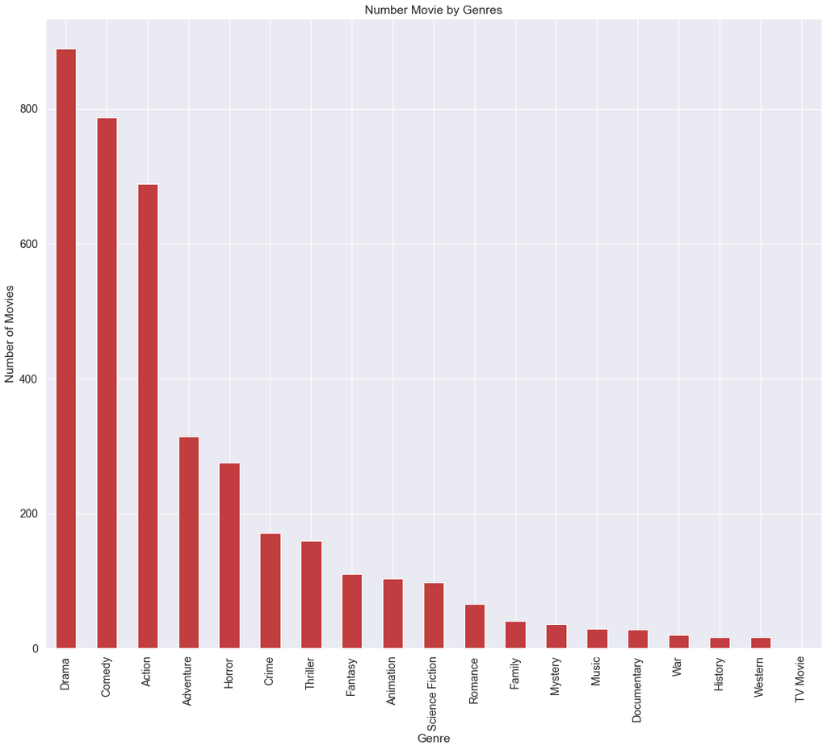

```python
# plot the data
fig, ax = plt.subplots(figsize=(18,15))

sns.set_palette("Set1", 20, .65)

# use unstack()
tmdb_data_genre.groupby(['genres']).count()['budget'].sort_values(ascending=False).plot(kind="bar",  ax=ax);
ax.set(xlabel='Genre', ylabel='Number of Movies', title = 'Number Movie by Genres')
```

From the above figure, we can see that Drama is the most frequent genre of movies, followed by comedy and action.

Now, let's figure out how the movie genre changed over time

[output not shown]

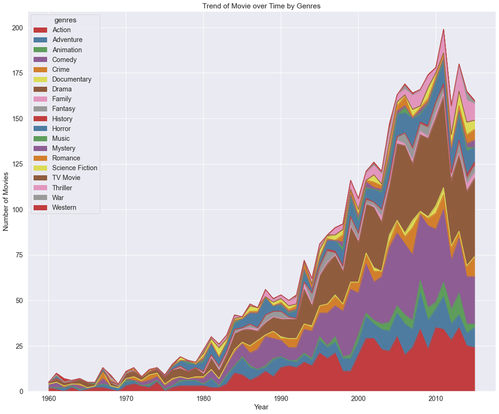

```python
plt.rcParams.update({'font.size': 22})
sns.set_style('darkgrid')

# plot the data
fig, ax = plt.subplots(figsize=(18,15))

sns.set_palette("Set1", 20, .65)

# use unstack()
tmdb_data_genre.groupby(['release_year', 'genres']).count()['budget'].unstack().plot.area(ax=ax);
ax.set(xlabel='Year', ylabel='Number of Movies', title = 'Trend of Movie over Time by Genres')
```

We can see that the popularity of movie releases is generally increased by the time.

### Research Question 7 (Which genres have the highest and lowest profit, budget and revenue?)

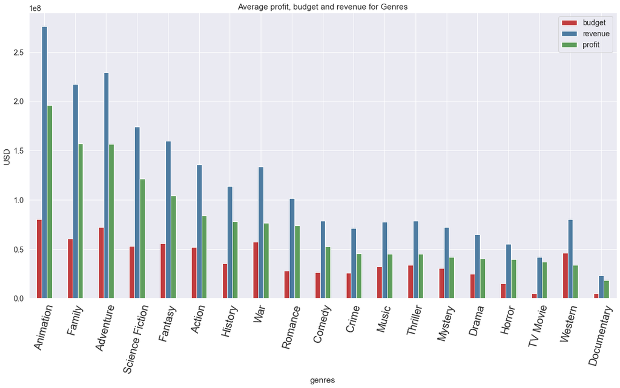

```python
# average profit, budget and revenue of each genres' movies
f,ax=plt.subplots(figsize=(20, 10))
tmdb_data[['genres', 'budget', 'revenue', 'profit']].groupby(['genres']).mean().sort_values(["profit", "revenue","budget"], ascending=False).plot(kind="bar",  ax=ax);
plt.xticks(rotation=75,fontsize=20)

ax.set(ylabel = 'USD', title = 'Average profit, budget and revenue for Genres')

plt.show()
```

## Conclusions

> There are some constrains and limitations in the current dataset. For example, the null and zero values for some variables. These values hinders the analysis and the rows conatining them have been removed. In additiion, the zero itself is a value in which sometimes the analysis would resulted in inaccurate outcomes. Hence data cleaning is a necessary part before analysing the data.